# PM2.5 Tutorial

Yuming Liu

October 13, 2020

## Load the Packages

We can use the “Packages” set-up on the right hand side to install the packages, or we could just run the code `install.packages('name', dependencies=TRUE, repos='http://cran.rstudio.com/')` from the Console to install new packages.

## Loading the Shapefiles

For ploting the PM2.5, we need to read the community area shapefiles and the shapefiles of the epa sensors. We firstly plot the shapefiles for CHicago Community Areas and then plot the EPA sensors.

```r
Chicago <- readOGR(".", "CommAreas")
```

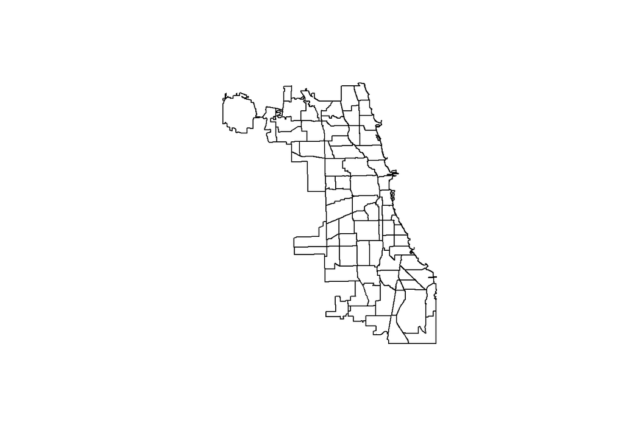

```r
plot(Chicago)
```

```r
EPA.Points <- readOGR(".", "PM2.5YearlyShapefile_CLEAN")
str(EPA.Points@data)
```

```
## 'data.frame':    24 obs. of  17 variables:
##  $ V1      : int  1 2 3 4 5 6 7 8 9 10 ...
##  $ AQS_SIT : int  170310001 170310022 170310052 170310057 170310076 170311016 170313103 170313301 170314007 170314201 ...
##  $ AQS_PAR : Factor w/ 1 level "PM2.5 - Local Conditions": 1 1 1 1 1 1 1 1 1 1 ...
##  $ CBSA_CO : int  16980 16980 16980 16980 16980 16980 16980 16980 16980 16980 ...
##  $ CBSA_NA : Factor w/ 2 levels "Chicago-Naperville-Elgin, IL-IN-WI",..: 1 1 1 1 1 1 1 1 1 1 ...
##  $ STATE_C : int  17 17 17 17 17 17 17 17 17 17 ...
##  $ STATE   : Factor w/ 3 levels "Illinois","Indiana",..: 1 1 1 1 1 1 1 1 1 1 ...
##  $ COUNTY_ : int  31 31 31 31 31 31 31 31 31 31 ...
##  $ COUNTY  : Factor w/ 8 levels "Cook","DuPage",..: 1 1 1 1 1 1 1 1 1 1 ...
##  $ SITE_LA : num  41.7 41.7 42 41.9 41.8 ...
##  $ SITE_LO : num  -87.7 -87.5 -87.7 -87.7 -87.7 ...
##  $ UNITS   : Factor w/ 1 level "ug/m3 LC": 1 1 1 1 1 1 1 1 1 1 ...
##  $ X14_DMPC: num  9.76 11.47 11.88 10.55 9.61 ...
##  $ X18_DMPC: num  8.87 9.01 9.22 9.34 8.82 ...
##  $ X2015MPC: num  11.11 10.88 9.98 12.67 11.01 ...
##  $ X2016MPC: num  8.49 8.4 8.63 9.2 9.12 ...
##  $ X2017MPC: num  8.77 8.45 8.72 8.82 8.32 ...
```

```r
EPA.Points@data
```

```
##    V1   AQS_SIT                  AQS_PAR CBSA_CO
## 1   1 170310001 PM2.5 - Local Conditions   16980
## 2   2 170310022 PM2.5 - Local Conditions   16980
## 3   3 170310052 PM2.5 - Local Conditions   16980
## 4   4 170310057 PM2.5 - Local Conditions   16980
## 5   5 170310076 PM2.5 - Local Conditions   16980
## 6   6 170311016 PM2.5 - Local Conditions   16980
## 7   7 170313103 PM2.5 - Local Conditions   16980
## 8   8 170313301 PM2.5 - Local Conditions   16980
## 9   9 170314007 PM2.5 - Local Conditions   16980
## 10 10 170314201 PM2.5 - Local Conditions   16980
## 11 11 170316005 PM2.5 - Local Conditions   16980
## 12 12 170434002 PM2.5 - Local Conditions   16980
## 13 13 170890003 PM2.5 - Local Conditions   16980
## 14 14 170890007 PM2.5 - Local Conditions   16980
```

[output cut: 85 more lines]

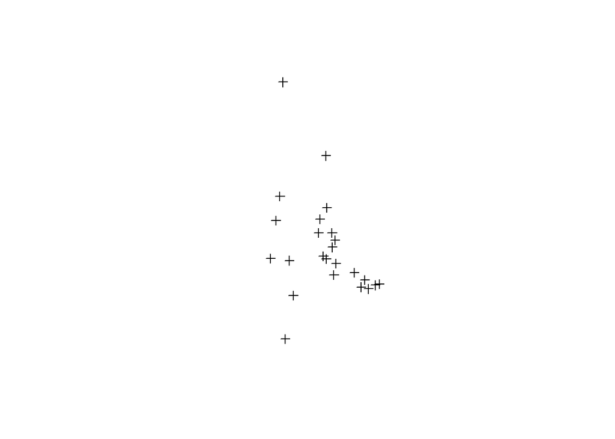

```r
plot(EPA.Points)
```

## Filtering the Sensors

We need to take out the sensor points that are located too far from Chicago. When we find the sensors that are close to Chicago, we name it as the `EPA.Points` sensors we need.

```r
test <- EPA.Points
test<- test[-c(24,25), ]
str(test@data)
```

```
## 'data.frame':    23 obs. of  17 variables:
##  $ V1      : int  1 2 3 4 5 6 7 8 9 10 ...
##  $ AQS_SIT : int  170310001 170310022 170310052 170310057 170310076 170311016 170313103 170313301 170314007 170314201 ...
##  $ AQS_PAR : Factor w/ 1 level "PM2.5 - Local Conditions": 1 1 1 1 1 1 1 1 1 1 ...
##  $ CBSA_CO : int  16980 16980 16980 16980 16980 16980 16980 16980 16980 16980 ...
##  $ CBSA_NA : Factor w/ 2 levels "Chicago-Naperville-Elgin, IL-IN-WI",..: 1 1 1 1 1 1 1 1 1 1 ...
##  $ STATE_C : int  17 17 17 17 17 17 17 17 17 17 ...
##  $ STATE   : Factor w/ 3 levels "Illinois","Indiana",..: 1 1 1 1 1 1 1 1 1 1 ...
##  $ COUNTY_ : int  31 31 31 31 31 31 31 31 31 31 ...
##  $ COUNTY  : Factor w/ 8 levels "Cook","DuPage",..: 1 1 1 1 1 1 1 1 1 1 ...
##  $ SITE_LA : num  41.7 41.7 42 41.9 41.8 ...
##  $ SITE_LO : num  -87.7 -87.5 -87.7 -87.7 -87.7 ...
##  $ UNITS   : Factor w/ 1 level "ug/m3 LC": 1 1 1 1 1 1 1 1 1 1 ...
##  $ X14_DMPC: num  9.76 11.47 11.88 10.55 9.61 ...
##  $ X18_DMPC: num  8.87 9.01 9.22 9.34 8.82 ...
##  $ X2015MPC: num  11.11 10.88 9.98 12.67 11.01 ...
##  $ X2016MPC: num  8.49 8.4 8.63 9.2 9.12 ...
##  $ X2017MPC: num  8.77 8.45 8.72 8.82 8.32 ...
```

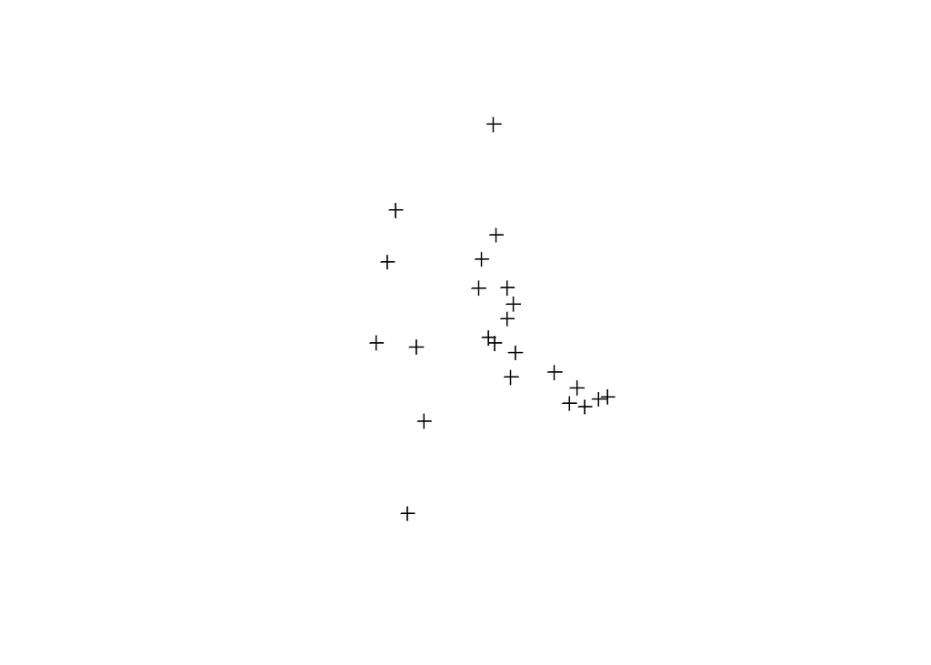

```r
plot(test)
```

```r
EPA.Points <- test
```

## Generate the IDW

To set up the grid, we define the sample grid based on the extent of the `EPA.Points` file.

```r
grid <-spsample(EPA.Points, type = 'regular', n = 10000)
```

Then we run the IDW function from the `gstat` package for the variable of interest in `EPA.Points`.

```r
idw <- idw(EPA.Points$X2017MPC ~ 1, EPA.Points, newdata = grid)
```

```
## [inverse distance weighted interpolation]
```

```r
idw.output = as.data.frame(idw)
names(idw.output)[1:3] <- c("long", "lat", "prediction")
```

Then we create the spatial points data frame.

```r
spg <- idw.output
coordinates(spg) <- ~ long + lat
```

The last step is to coerce the grid to Spatial Pixels Data Frame and to raster.

```r
gridded(spg) <- TRUE

raster_idw <- raster(spg)
```

## Set the Projection

We use the following code to set the standard of the projection.

```r
projection(raster_idw) <- CRS("+init=epsg:4326")
```

## Plot the IDW Results

Firstly, we mask raster by Chicago polygon file.

```r
masked_idw <- mask(raster_idw, Chicago)
```

Then we plot the masked raster.

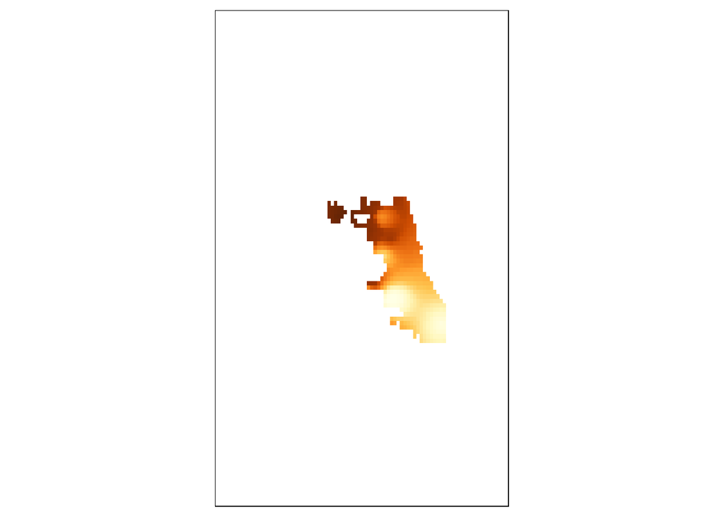

```r
tm_shape(masked_idw) + tm_raster("prediction", style = "quantile", n = 100, legend.show = FALSE)
```

The previous raster file only shows the IDW result. Then We plot the masked raster with point emissions.

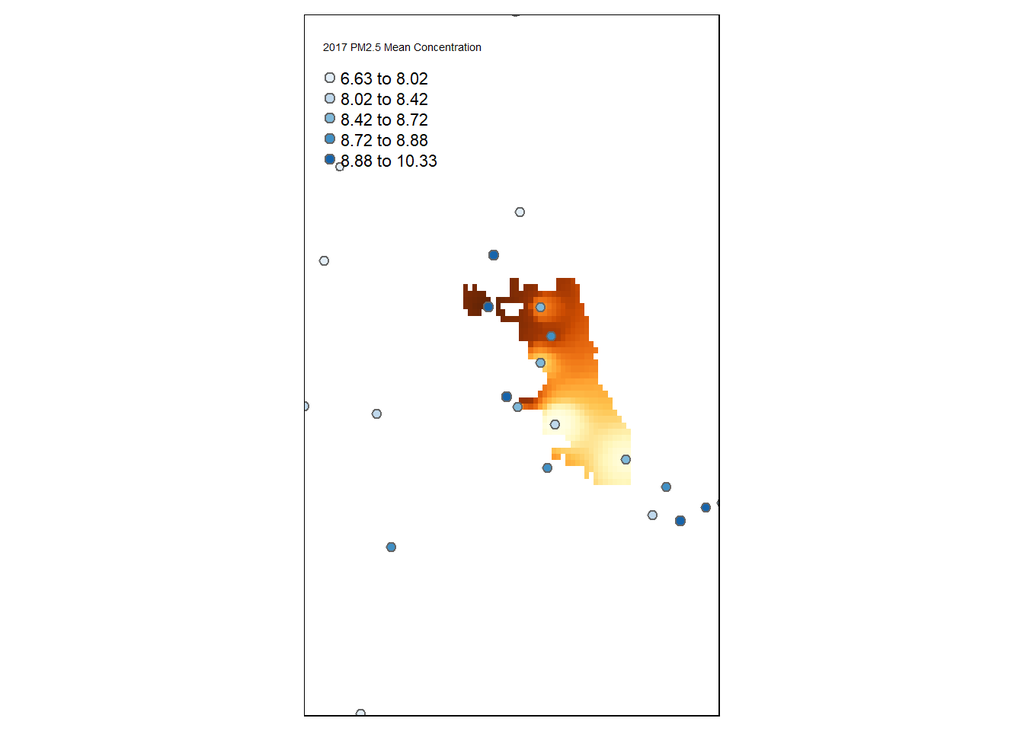

```r
tm_shape(masked_idw) + tm_raster("prediction", style = "quantile", n = 100, legend.show = FALSE) +
  tm_shape(EPA.Points) + tm_bubbles(size = "X2017MPC", col = "X2017MPC", palette = "Blues",
                                    scale = 0.5, style = "quantile", legend.size.show = FALSE, title.col = "2017 PM2.5 Mean Concentration")
```

```r
tmap_mode("view")
```

```
## tmap mode set to interactive viewing
```

```r
tm_shape(masked_idw) +
  tm_raster("prediction", style = "quantile",
            n = 100, alpha = 0.4, legend.show = FALSE) +
  tm_shape(EPA.Points) +
  tm_bubbles(col = "X2017MPC",
             palette = "Blues",
             scale = .5,
             style = "quantile",
             title.col = "2017 Mean PM2.5")
```

[interactive chart not shown]

```r
tmap_mode("plot")
```

```
## tmap mode set to plotting
```

From the code above, we use `tm_bubbles` to plot the sensors. The function allows us to change colors, sizes, and display styles of the sensor. For example, we applied the color (`palette`) as `"Blues"` for our map, and we could change it to any colors from `RColorBrewer::display.brewer.all`. Also, we use .5 for the `scale` and `"quantile"` as the `style`. We could increase the scale to enlarge the EPA sensors on the map and change the style as one of “fixed”, “sd”, “equal”, “pretty”, “quantile”, “kmeans”, “hclust”, “bclust”, or “fisher”. If we change the color to `"Greens"` and the style to `"sd"`, we could get the following map:

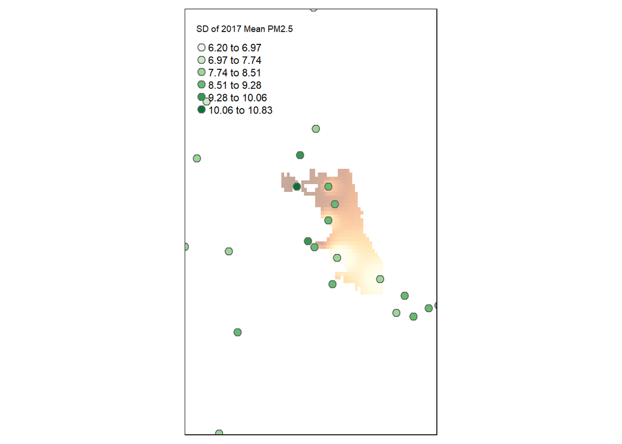

```r
tm_shape(masked_idw) +
  tm_raster("prediction", style = "quantile",
            n = 100, alpha = 0.4, legend.show = FALSE) +
  tm_shape(EPA.Points) +
  tm_bubbles(col = "X2017MPC",
             palette = "Greens",
             scale = .6,
             style = "sd",
             title.col = "SD of 2017 Mean PM2.5")
```

We can also scoll the map to zoom in and zoom out. Moreover, `tm_dots` is also a similar option for ploting some dot locations on the map, and it has almost the same coding structure as `tm_bubbles`. For more features of these commands, We can find the document of `tm_bubbles` from this link here: https://www.rdocumentation.org/packages/tmap/versions/1.2/topics/tm_bubbles.

We plot the masked raster with Community Area overlay added.

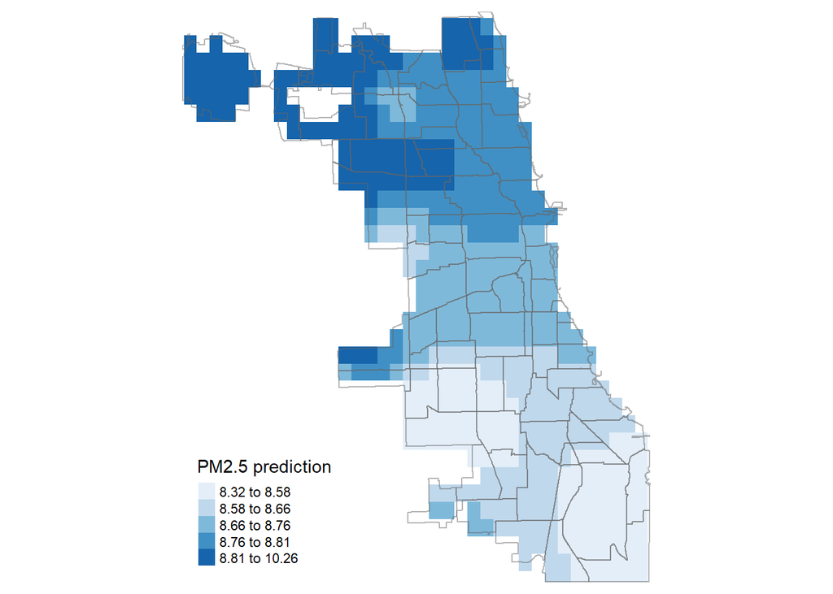

```r
tm_shape(masked_idw, bbox=Chicago) +
  tm_raster("prediction", style = "quantile", pal = "Blues", n = 5, legend.show = TRUE, title = "PM2.5 prediction") +
  tm_shape(Chicago) + tm_borders(alpha=.5,) +
  tm_layout(frame = F, legend.position = c("left","bottom"))
```

## Combine the shapefiles and the PM2.5 values

Extracting the Pixel Values from the Raster for chicago Community Areas and removing NAs, we have the cleaned masked IDW results.

```r
chi.ave <- raster::extract(masked_idw, Chicago)

chi.ave <- lapply(chi.ave, na.omit)
```

Then we calculate the average value by Community Areas.

```r
ca.ave <- lapply(chi.ave, FUN=mean)
ca.ave  <- unlist(ca.ave )
```

We attach the Mean Values to Community Area information by grabing Community Area names/IDs from Chicago shapefiles.

```r
chi.info <- cbind(as.integer(as.character(Chicago@data$area_numbe)))
head(chi.info)
```

```
##      [,1]
## [1,]   35
## [2,]   36
## [3,]   37
## [4,]   38
## [5,]   39
## [6,]    4
```

Then we attach EPA Average numbers to the data frame.

```r
chica.final <- cbind(chi.info, ca.ave)
colnames(chica.final) <- c("area_numbe", "PM2.5")
as.data.frame(chica.final)
```

```
##    area_numbe    PM2.5
## 1          35 8.713258
## 2          36 8.690499
## 3          37 8.673084
## 4          38 8.683375
## 5          39 8.676078
## 6           4 8.803450
## 7          40 8.650915
## 8          41 8.661904
## 9          42 8.642987
## 10          1 8.808639
## 11         11 8.831909
## 12         12 8.859270
## 13         13 8.785987
## 14         14 8.776996
```

[output cut: 63 more lines]

```r
Chicago<- merge(Chicago, chica.final, by = "area_numbe")
head(Chicago@data)
```

```
##    area_numbe perimeter       community shape_len shape_area area comarea
## 29         35         0         DOUGLAS  31027.05   46004621    0       0
## 30         36         0         OAKLAND  19565.51   16913961    0       0
## 31         37         0     FULLER PARK  25339.09   19916705    0       0
## 32         38         0 GRAND BOULEVARD  28196.84   48492503    0       0
## 33         39         0         KENWOOD  23325.17   29071742    0       0
## 34          4         0  LINCOLN SQUARE  36624.60   71352328    0       0
##    area_num_1 comarea_id Mean_NDVI    PM2.5
## 29         35          0  8.710446 8.713258
## 30         36          0  8.701196 8.690499
## 31         37          0  8.678781 8.673084
## 32         38          0  8.680210 8.683375
## 33         39          0  8.678108 8.676078
## 34          4          0  8.804246 8.803450
```

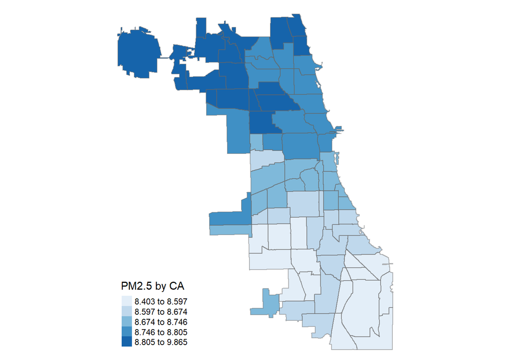

```r
tm_shape(Chicago) +
  tm_fill("PM2.5", style = "quantile", n = 5, pal = "Blues",legend.show = TRUE, title = "PM2.5 by CA") +
  tm_shape(Chicago) + tm_borders(alpha=.5) +
  tm_layout(frame = F, legend.position = c("left","bottom"))
```

## Save the Results

Finally, we write the data to a CSV file.

```r
write.csv(chica.final, "PM5_aggregated.csv")
```